# Homework #1

Matt Quintiere and Rohit Gunda

2023-10-16

### Setup

```r
library(tidyverse)
library(tidymodels)
library(dplyr)
library(knitr)
library(palmerpenguins)
library(GGally)
library(factoextra)
library(psych)
library(patchwork)
library(factoextra)
library(cluster)
library(mclust)
library(kernlab)
```

### Introduction

```r
penguins_raw <- penguins_raw
names(penguins_raw)
```

```
##  [1] "studyName"           "Sample Number"       "Species"
##  [4] "Region"              "Island"              "Stage"
##  [7] "Individual ID"       "Clutch Completion"   "Date Egg"
## [10] "Culmen Length (mm)"  "Culmen Depth (mm)"   "Flipper Length (mm)"
## [13] "Body Mass (g)"       "Sex"                 "Delta 15 N (o/oo)"
## [16] "Delta 13 C (o/oo)"   "Comments"
```

Data Introduction: The data set that we aim to analyze contains data on 344 penguins. This data set contains data on 3 species of penguins (Adelie, Chinstrap, and Gentoo) from 3 islands in the Palmer Archipelago (Torgerson, Biscoe, and Dream). There are 17 variables in the dataset, and they consist of the following:

- **studyName:** Sampling expedition from which data were collected, generated, etc.
- **Sample Number:** an integer denoting the continuous numbering sequence for each sample
- **Species:** a character string denoting the penguin species (Adelie, Chinstrap, Gentoo)
- **Region:** a character string denoting the region of Palmer LTER sampling grid
- **Island:** a character string denoting the island near Palmer Station where samples were collected
- **Stage:** a character string denoting reproductive stage at sampling
- **Individual ID:** a character string denoting the unique ID for each individual in data set
- **Clutch Completion:** a character string denoting if the study nest observed with a full clutch, i.e., 2 eggs
- **Date Egg:** a date denoting the date study nest observed with 1 egg (sampled)
- **Culmen Length (mm):** a number denoting the length of the dorsal ridge of a bird’s bill (millimeters)
- **Culmen Depth (mm):** a number denoting the depth of the dorsal ridge of a bird’s bill (millimeters)
- **Flipper Length (mm):** an integer denoting the length penguin flipper (millimeters)
- **Body Mass (g):** an integer denoting the penguin body mass (grams)
- **Sex:** a character string denoting the sex of an animal
- **Delta 15 N:** a number denoting the measure of the ratio of stable isotopes 15N:14N
- **Delta 13 C:** a number denoting the measure of the ratio of stable isotopes 13C:12C
- **Comments:** a character string with text providing additional relevant information for data

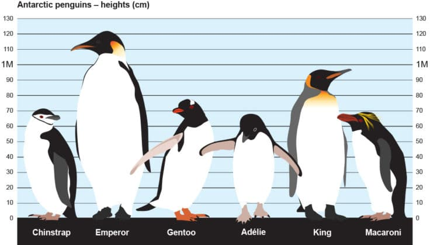

Motivation: We decided to use this data set for our analysis because we were interested to see if there was any variation in some of the key metrics between penguins of different species. To gain a better understanding of these key metrics, we will be using unsupervised learning techniques of Principal Component Analysis (PCA), Factor Analysis, and Cluster Analysis to get a better understanding of how the metrics are related and can be useful in predicting the species of a penguin on these islands. The metrics we will be using are the numeric variables of `Culmen Length (mm)`, `Culmen Depth (mm)`, `Flipper Length (mm)`, and `Body Mass (g)`. We have also kept `Species`, `Island`, and `Sex`. While we will be focusing on analyzing the numeric variables to get a better understanding of how they relate to the penguins’ species, we may be interested in the future in conducting a similar analysis to get better understanding of how these numeric variables relate to a penguins’ sex or island. Therefore, we will keep the `sex` and `island` variables. We have removed `Region`, `studyName`, `Sample Number`, `Stage`, `Individual ID`, `Clutch Completion`, `Data Egg`, `Delta 15 N`, `Delta 13 C`, and `Comments` as we believe that they are not relevant for our analysis. We will now go ahead and clean the data set to get it to the version that we want use for our analysis.

```r
penguins_mod <- penguins_raw |>
  select(-studyName, -`Sample Number`, -Region, -`Individual ID`, -Stage,
         -`Clutch Completion`, -`Date Egg`, -`Delta 15 N (o/oo)`,
         -`Delta 13 C (o/oo)`, -Comments)
```

```r
penguins2 <- penguins_mod[rowSums(is.na(penguins)) < 2, ]
penguins2 <- penguins2 |>
  mutate(
    Species = case_when(
      Species == "Adelie Penguin (Pygoscelis adeliae)" ~ "Adelie",
      Species == "Gentoo penguin (Pygoscelis papua)" ~ "Gentoo",
      Species == "Chinstrap penguin (Pygoscelis antarctica)" ~ "Chinstrap"
    )
  )
duplicated(penguins2)
```

Here we did some initial data cleaning by removing rows that had 2 or more NA values, which removed all the NA values in our numeric variable columns. We also shortened the names of the species to make it easier when writing our report. We then checked for duplicates in our data set and found none to remove. Now, we will check for extreme outliers to remove in our data set:

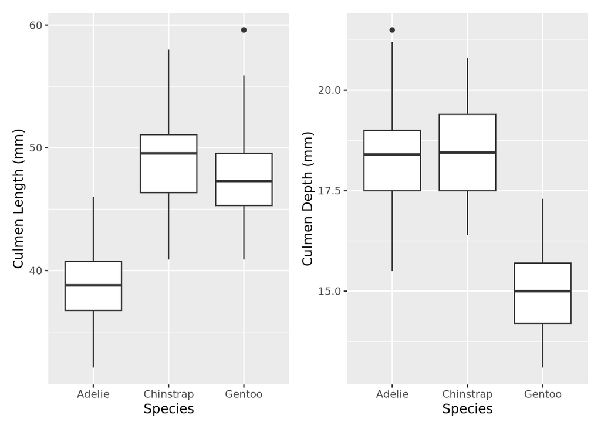

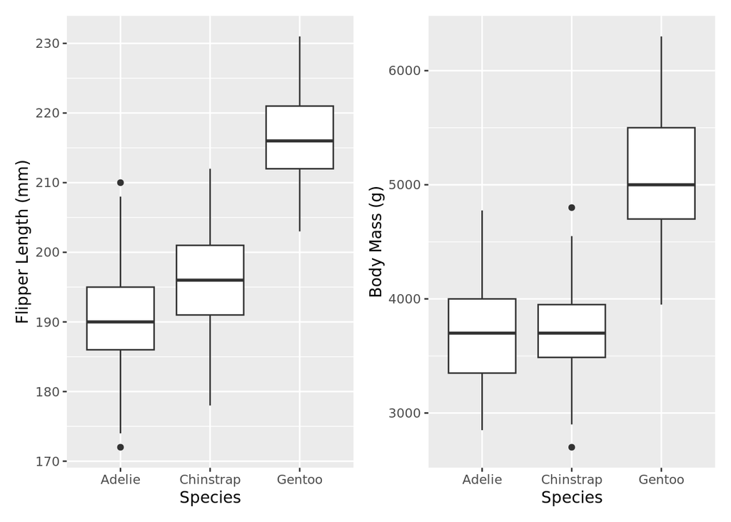

Through viewing these boxplots of our numeric variables and how they relate to the species of the penguins, we can tell that there are no extreme outliers, which means that we can use this data set for our unsupervised learning analysis:

| Species | Island | Culmen Length (mm) | Culmen Depth (mm) | Flipper Length (mm) | Body Mass (g) | Sex |
| --- | --- | --- | --- | --- | --- | --- |
| Adelie | Torgersen | 39.1 | 18.7 | 181 | 3750 | MALE |
| Adelie | Torgersen | 39.5 | 17.4 | 186 | 3800 | FEMALE |
| Adelie | Torgersen | 40.3 | 18.0 | 195 | 3250 | FEMALE |
| Adelie | Torgersen | 36.7 | 19.3 | 193 | 3450 | FEMALE |
| Adelie | Torgersen | 39.3 | 20.6 | 190 | 3650 | MALE |
| Adelie | Torgersen | 38.9 | 17.8 | 181 | 3625 | FEMALE |

### PCA

Our first unsupervised learning technique to learn more about our data set will be the PCA. To explore the principal components of our data set to explain the variability, we have to isolate the numeric variables in the data set, which are `Culmen Length (mm)`, `Culmen Depth (mm)`, `Flipper Length (mm)`, and `Body Mass (g)`. The reason we can only use numeric variables is because the PCA relies on linear algebra calculations to find a linear combination that explains majority of the total variance, which can only be used with numeric data.

| Culmen Length (mm) | Culmen Depth (mm) | Flipper Length (mm) | Body Mass (g) |
| --- | --- | --- | --- |
| 39.1 | 18.7 | 181 | 3750 |
| 39.5 | 17.4 | 186 | 3800 |
| 40.3 | 18.0 | 195 | 3250 |
| 36.7 | 19.3 | 193 | 3450 |
| 39.3 | 20.6 | 190 | 3650 |
| 38.9 | 17.8 | 181 | 3625 |

Let’s visualize how correlated these variables are by creating a correlation plot:

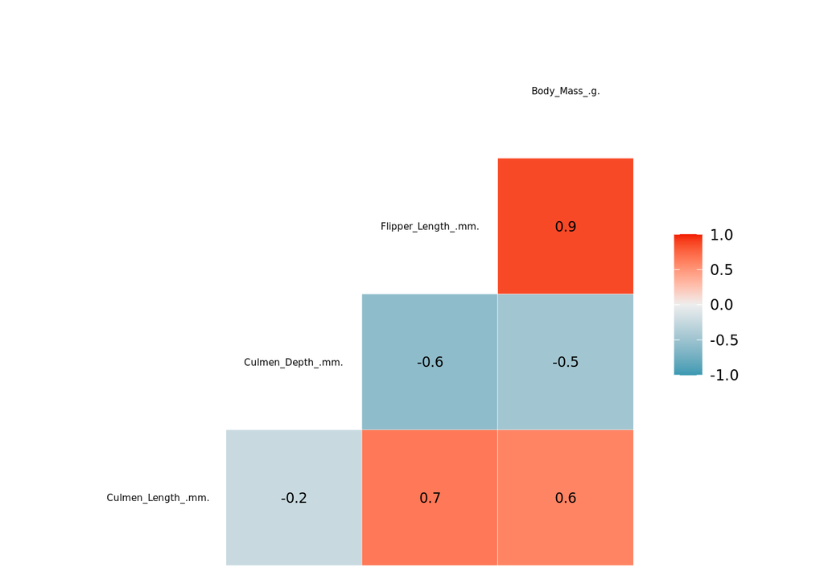

From the correlation matrix, we can see that `Body Mass (g)` is very positively correlated with `Flipper Length (mm)`. Also `Culmen Length (mm)` has a somewhat strong correlation with `Flipper Length (mm)`, while `Culmen Depth (mm)` has a negative correlation with all of the variables and does not have a strong correlation with any of the variables.

```r
pca = prcomp(pca_penguins2, scale = TRUE)
summary(pca)
```

```
## Importance of components:
##                           PC1    PC2     PC3     PC4
## Standard deviation     1.6594 0.8789 0.60435 0.32938
## Proportion of Variance 0.6884 0.1931 0.09131 0.02712
## Cumulative Proportion  0.6884 0.8816 0.97288 1.00000
```

Running the PCA calculations out using the prcomp tool, we see that the first two principal components are responsible for about 88% percent of the data. Let’s create a screeplot to visualize this:

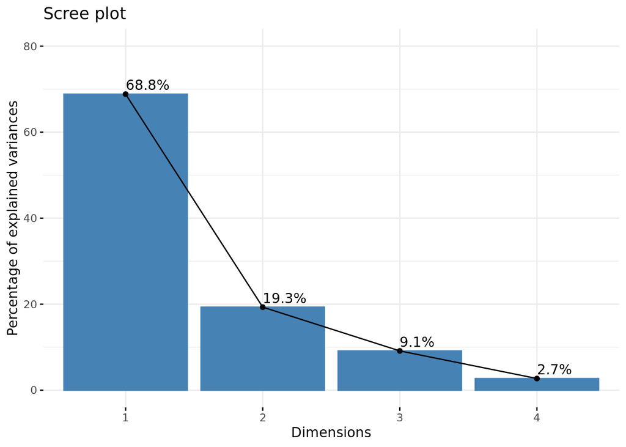

Now let’s apply the Kaiser rule to select the number of components thar we will use in the PCA:

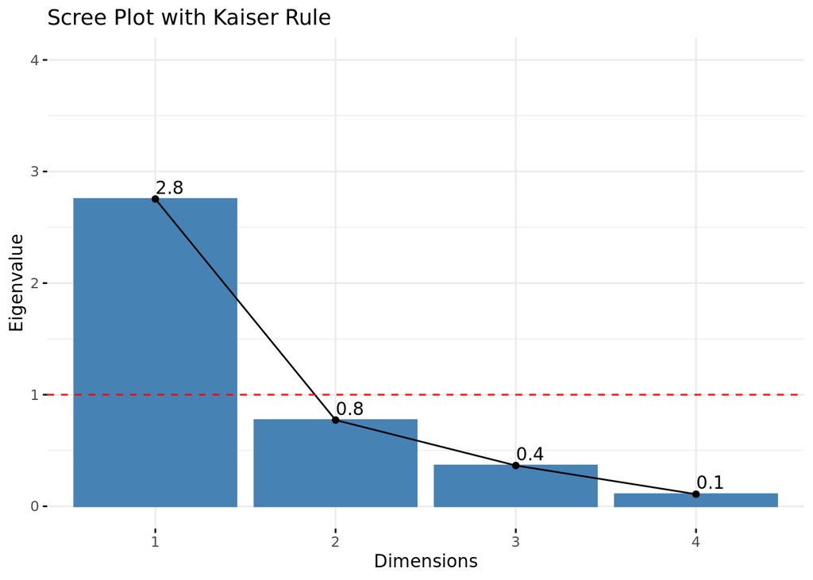

Only our first principal component has an eigenvalue greater than one, so our analysis will focus on the first principal component to start, which explains about 69% of the variability and is the maximum variance direction in the data. However, we may still use the second principal component if necessary. Now let’s look at what variables contribute the most to our first principal component:

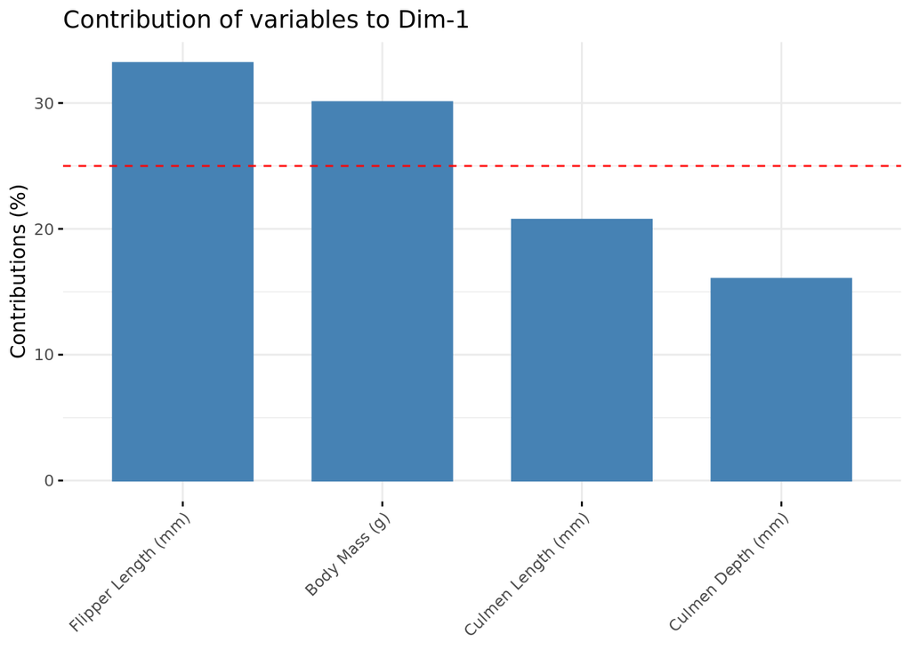

On average, each variable is expected to contributed 25% to the first principal component. However, only two of those variables `Flipper Length (mm)` and `Body Mass (g)` contribute over 25% to the first principal component. We should note that a reason that this could occur is that `Flipper Length (mm)` and `Body Mass (g)` are highly correlated. Let’s visualize this correlated relationship with respect to `Species`:

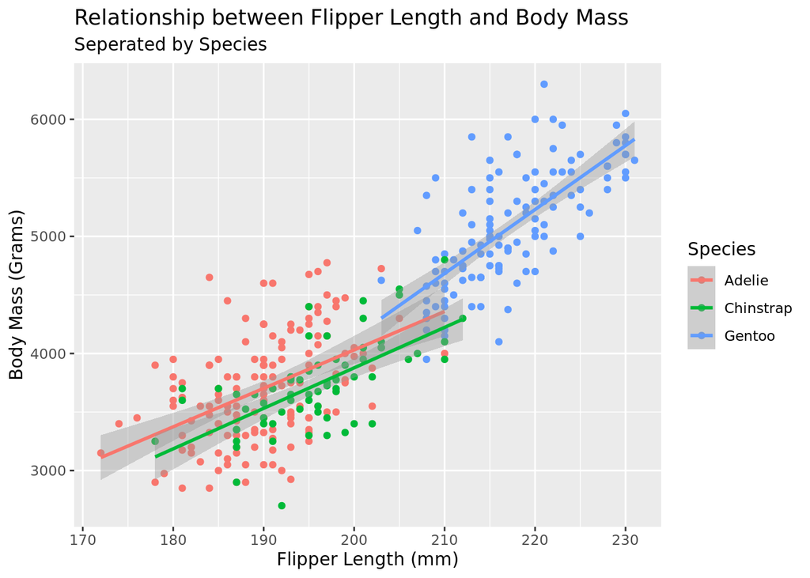

From this chart, we can see the differentiation of the Gentoo species from the Adelie and Chinstrap species of penguins, as the Gentoo species tends to have a greater body mass and flipper length. However, Adelie and Chinstrap are not differentiable based on their flipper length and body mass relationship. Therefore, the first principal component is an overall measure for the size of the penguins which differentiates the Gentoos. Another thing to note is that `Body Mass (g)` and `Flipper Length (mm)` display a strong positive correlation for each of the species as predicted in the correlation plot. Let’s circle back to the second principal component, so that we can find a way to differentiate the Adelie and Chinstrap species as they are similar sizes:

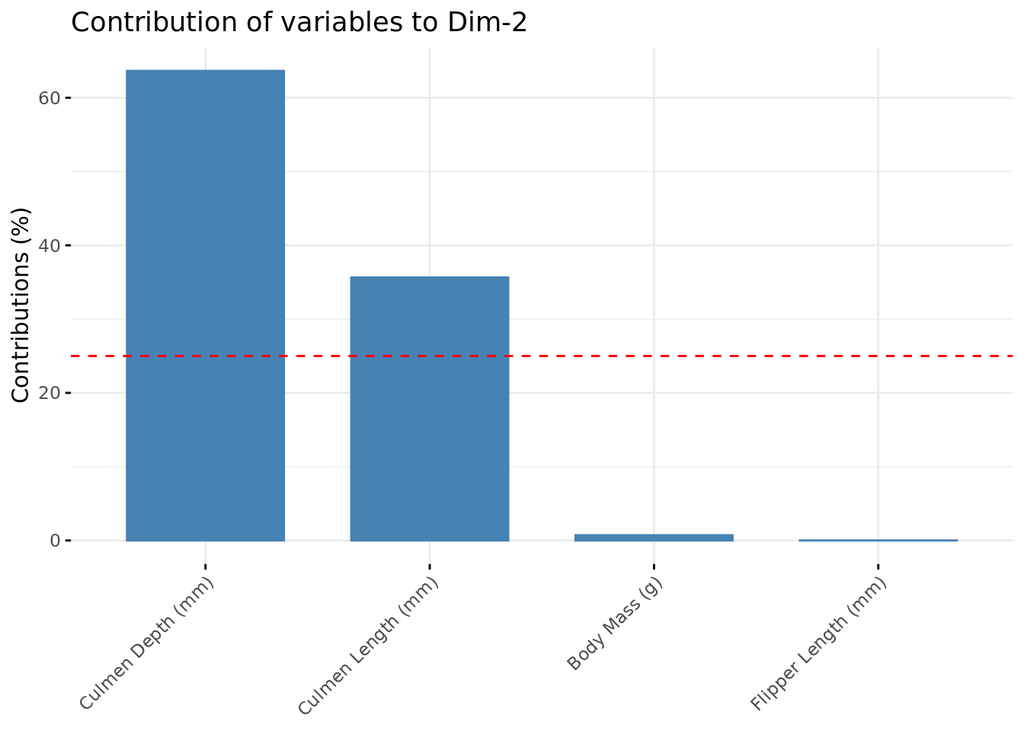

In the second principal component, the two other variables contribute more than expected. Let’s visualize the relationship of `Culmen Length (mm)` and `Culmen Depth (mm)` with respect to species:

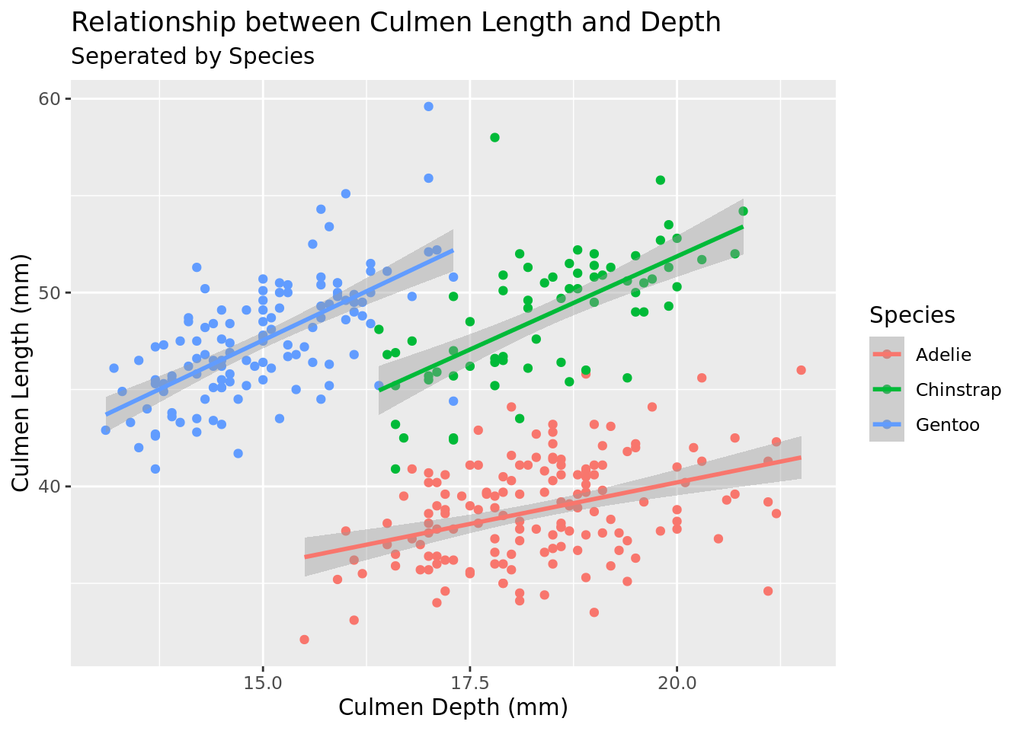

The second principal component is explained primarily by `Culmen Length (mm)` and `Culmen Depth (mm)`. From looking at the scatter plot above, we can determine that Chinstrap penguins have similar culmen depths as Adelie penguins, but much larger culmen lengths. Also, despite being smaller penguins in size, the Chinstrap and Adelie penguins have larger culmen depths than Gentoo penguins. Gentoo penguins; however, have a much larger culmen length than Adelie penguins. Also, it is interesting to note that `Culmen Depth (mm)` and `Culmen Length (mm)` were not strongly correlated based on our correlation matrix and were also negatively correlated. However, when the relationship of these variables are separated by species, there is at least a somewhat strong positive correlation.

### Factor Analysis

After determining the meaning of our first two principal components and using the PCA to attempt to explain the total variance, we will move on to completing a factor analysis in order to better explain the variance and covariance of the observed variables in our data set by a set of fewer latent variables. Let’s test if our factor analysis will run:

```r
det(cor(pca_penguins2))
```

```
## [1] 0.08429567
```

Our determinant is positive, so that means our factor analysis will most likely run.

```r
pa <- fa(r = pca_penguins2,
         nfactors =2,
         rotate = "varimax",
         fa = "pa",
         resdiuals = TRUE)
ml <- fa(r = pca_penguins2,
         nfactors =2,
         rotate = "varimax",
         fa = "ml",
         resdiuals = TRUE)
```

```r
ml
```

```
## Factor Analysis using method =  minres
## Call: fa(r = pca_penguins2, nfactors = 2, rotate = "varimax", fa = "ml",
##     resdiuals = TRUE)
## Standardized loadings (pattern matrix) based upon correlation matrix
##                       MR1   MR2   h2    u2 com
## Culmen Length (mm)   0.71  0.11 0.51 0.489 1.0
## Culmen Depth (mm)   -0.22 -0.76 0.63 0.371 1.2
## Flipper Length (mm)  0.85  0.52 0.99 0.005 1.7
## Body Mass (g)        0.78  0.40 0.77 0.232 1.5
##
##                        MR1  MR2
## SS loadings           1.88 1.03
## Proportion Var        0.47 0.26
## Cumulative Var        0.47 0.73
## Proportion Explained  0.65 0.35
## Cumulative Proportion 0.65 1.00
##
## Mean item complexity =  1.3
## Test of the hypothesis that 2 factors are sufficient.
##
## df null model =  6  with the objective function =  2.47 with Chi Square =  838.08
## df of  the model are -1  and the objective function was  0
##
## The root mean square of the residuals (RMSR) is  0
## The df corrected root mean square of the residuals is  NA
##
## The harmonic n.obs is  342 with the empirical chi square  0  with prob <  NA
## The total n.obs was  342  with Likelihood Chi Square =  0  with prob <  NA
##
## Tucker Lewis Index of factoring reliability =  1.007
## Fit based upon off diagonal values = 1
## Measures of factor score adequacy
##                                                    MR1  MR2
## Correlation of (regression) scores with factors   0.92 0.79
## Multiple R square of scores with factors          0.85 0.63
## Minimum correlation of possible factor scores     0.71 0.26
```

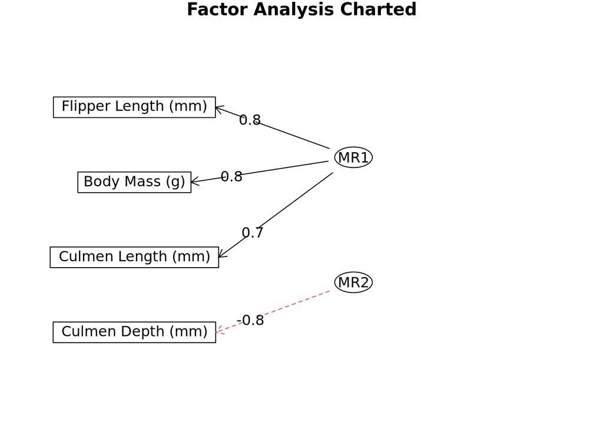

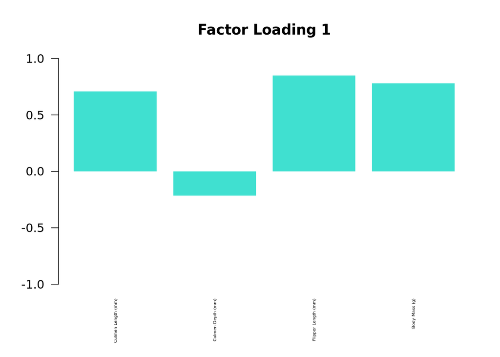

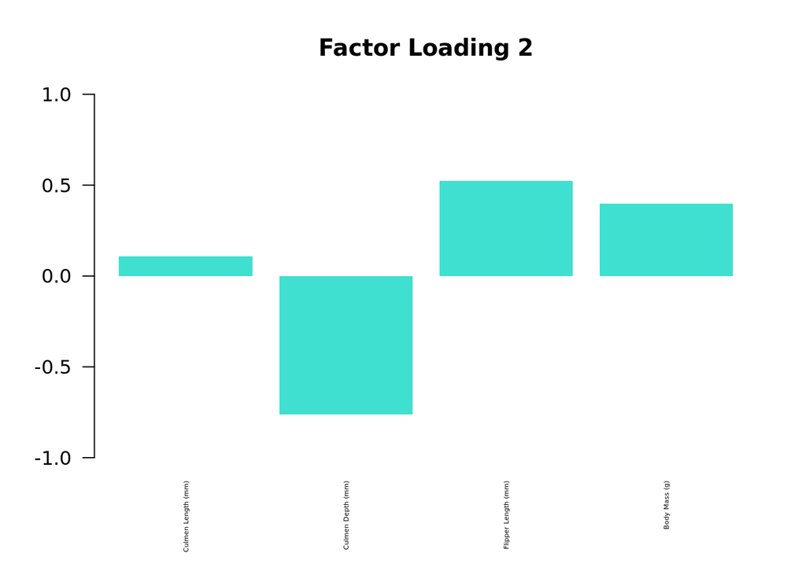

Similar to the PCA, we were able reduce our data into two-dimensions with the size of the penguin and the shape of the beak. It is interesting to note that the first loading factor did a much better job at explaining the variances and covariances of the variables than the second loading factor. This may have occurred because `Culmen Depth (mm)` is not that strongly correlated with the other numeric variables and `Culmen Depth (mm)` is the main variable in the second loading factor.

Also, our PCA and factor analysis may have produced slightly different results because all of our variables are not in the same units. The reason for this is because it is impossible to convert grams to millimeters, so the `Body Mass (g)` variable has different units than the rest of the numeric variables.

Let’s move onto our final unsupervised learning method to further explore our data before we make final conclusions.

### Cluster Analysis

We will now be conducting a cluster analysis to try to identify patterns within our data set. Our initial guess for the number of clusters was 3 because it signifies the number of species of penguins in the data set. We believe that the clusters should represent the species of the penguin instead the island that they are from because there is a higher variation between species of penguin versus the island that the penguin resides on. The islands could all have an even distribution of species of penguins, so it makes more sense that species is the cluster we should be focusing on.

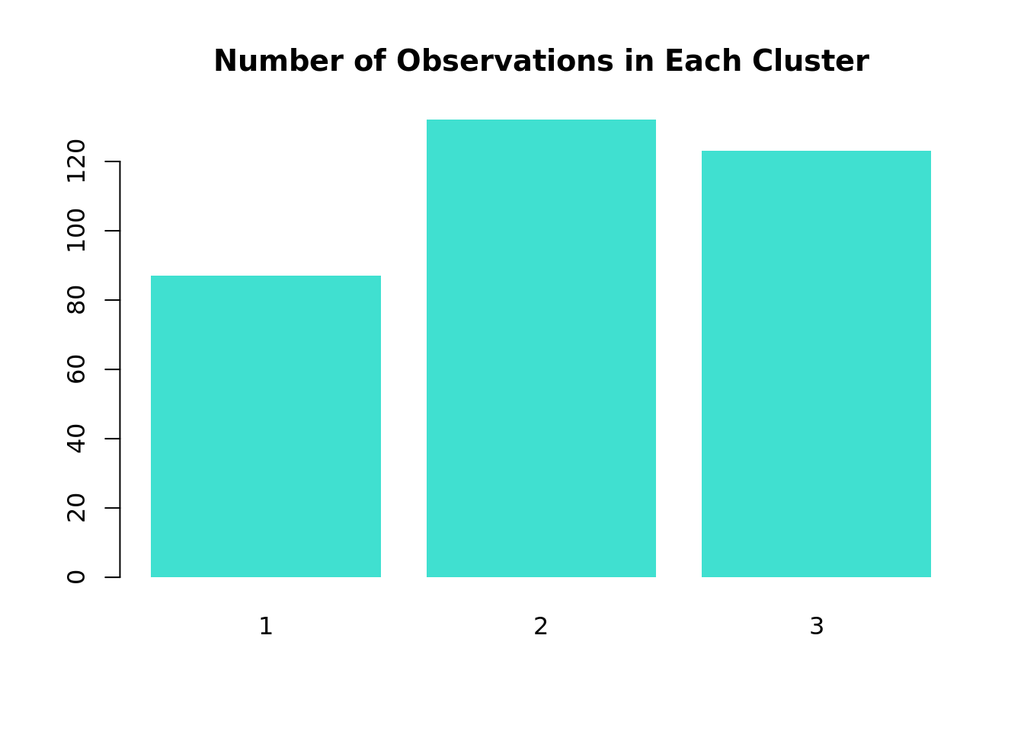

Now let’s interpret the centers:

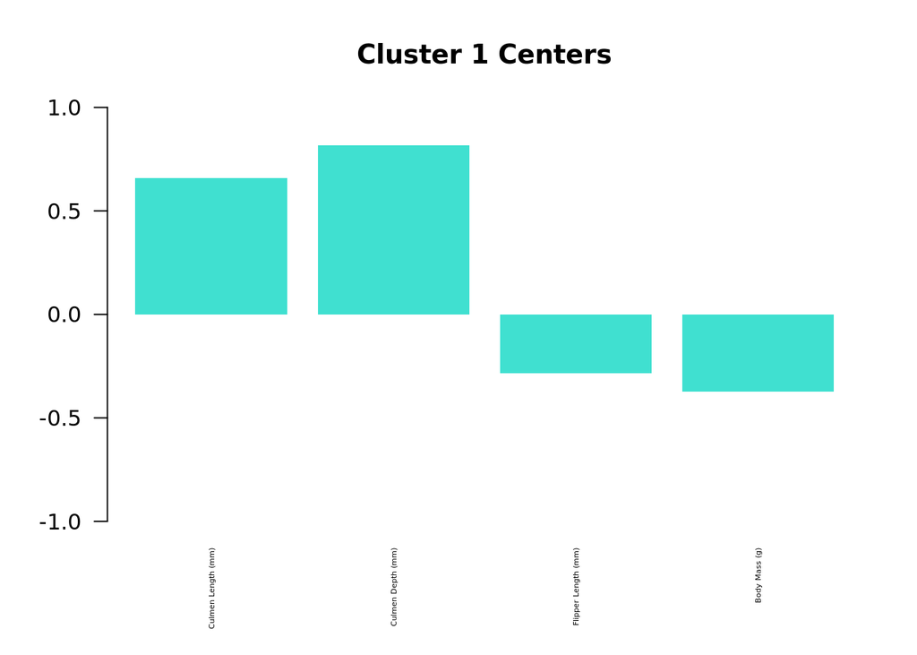

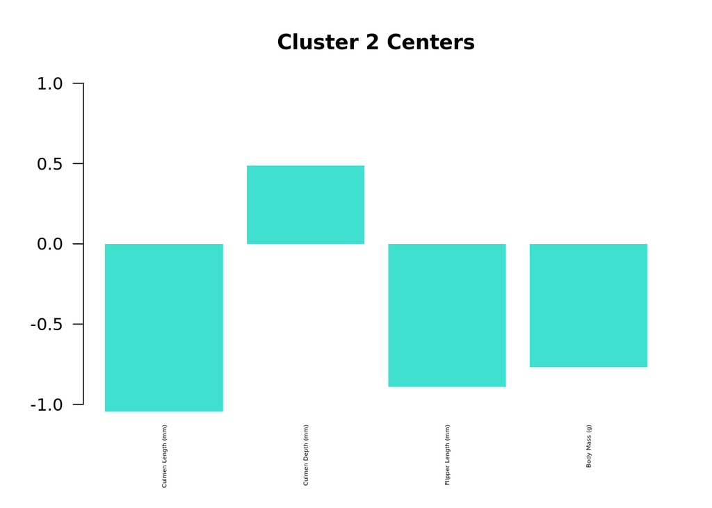

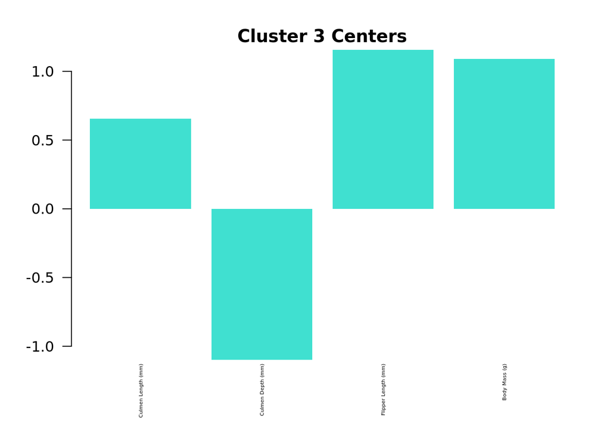

One cluster seems to have the characteristics of having a longer `Culmen depth (mm)`, as seen by the analysis of the centers of our data.

Another cluster seems to have the characteristics of having a much lower `Culmen length (mm)`.

The final cluster seems to have the characteristics of having a longer `Flipper Length (mm)` and `Body Mass (g)`.

Based on this, we can see some of the major differences between each cluster. Specifically, we see these cluster-specific differences in characteristics such as `Culmen length/depth (mm)`, `Body Mass (g)`, and `Flipper Length (mm)`.

Now, let us confirm the most optimal amount of clusters, per the silhouette method.

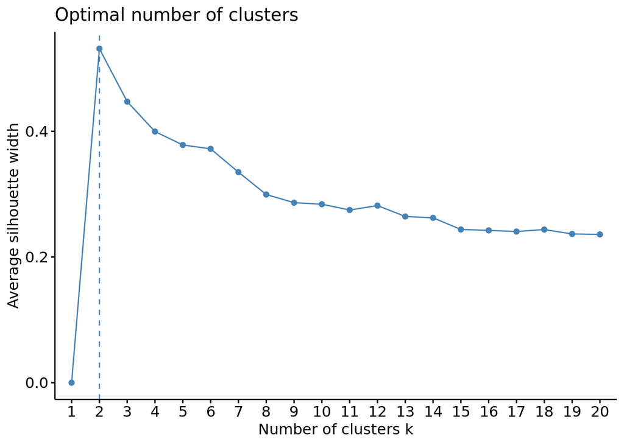

```r
fit.ker <- kkmeans(as.matrix(pca_penguins2), centers=3, kernel="rbfdot")
```

```
## Using automatic sigma estimation (sigest) for RBF or laplace kernel
```

```r
centers(fit.ker)
```

```
##          [,1]     [,2]     [,3]     [,4]
## [1,] 45.52479 17.15726 205.9573 4515.385
## [2,] 41.51870 18.08293 189.6748 3520.528
## [3,] 44.98137 16.02059 208.6863 4663.480
```

```r
size(fit.ker)
```

```
## [1] 117 123 102
```

```r
withinss(fit.ker)
```

```
## [1] 3532156687 2182831135 3212666301
```

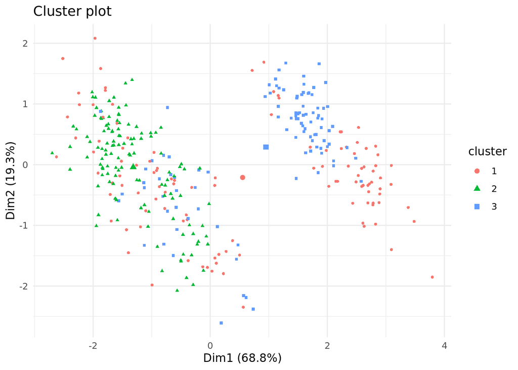

```r
object.ker = list(data = pca_penguins2, cluster = fit.ker@.Data)

fviz_cluster(object.ker, geom = c("point"), ellipse=F,pointsize=1) +
  theme_minimal()
```

Per our above analysis on the optimal number of clusters, as well as the plot showing the relationship between `Flipper Length (mm)` and `Body Mass (g)`, we will now use 2 clusters as the “guess” when analyzing our centers.

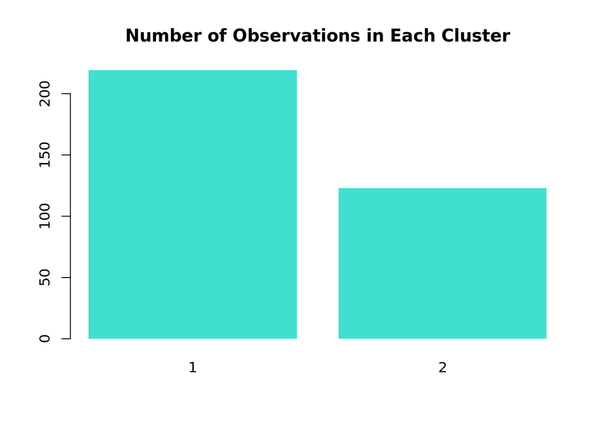

```r
y = 2

fit = kmeans(scale(pca_penguins2), centers=y, nstart=1000)
groups = fit$cluster
barplot(table(groups), col="turquoise", main ="Number of Observations in Each Cluster", border = NA)
```

Interpret the centers:

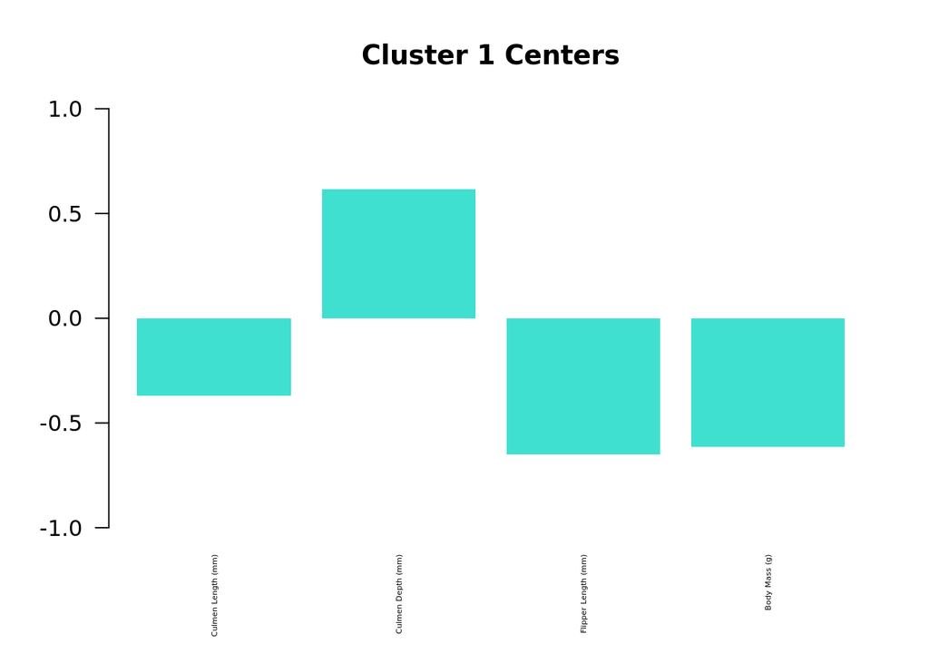

```r
centers=fit$centers

barplot(centers[1,], las=2, col="turquoise", ylim= c(-1,1), cex.names = 0.35, border = NA,
        main = "Cluster 1 Centers")
```

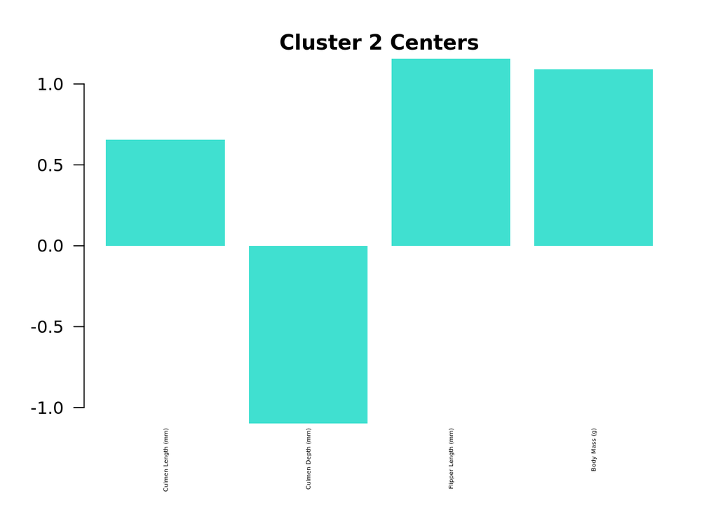

```r
barplot(centers[2,], las=2, col="turquoise", ylim= c(-1,1), cex.names = 0.35, border = NA,
        main = "Cluster 2 Centers")
```

Now, the differences between both clusters are much more distinct. `Culmen Depth (mm)` is notably higher in the first cluster, whereas the other 3 key continuous variables (`Culmen Length (mm)`, `Flipper Length (mm)`, and `Body Mass (g)`), are noticeably higher in the second one.

To conclude, we originally thought that there would be three clusters, as species was a clear defining categorical variable that can be used to distinguish between penguins. However, after looking at the plots of the principal components, as well as the optimal cluster analysis, we can conclude that there are 2 clusters in our data.

### Conclusion

It is essential to outline some of the main distinguishing factors between the 3 species of penguins that we are analyzing. Upon looking at the plot in the PCA, which displays the relationship between `Flipper Length (mm)` and `Body Mass (g)` with respect to species, we can see that the Gentoo penguins are in its own group in the top right, while the Adelie and Chinstrap penguins are clumped together, as they are similar in size. In fact, Gentoo penguins are the third largest species of penguins, while the Chinstrap and Adelie penguins are 5th and 6th largest, respectively. With regards to our cluster analysis, we originally guessed that there would be 3 clusters, but upon analyzing the optimal number of clusters, and visualizing the data through the first two principal components allowed us to conclude that there were in fact 2 clusters, albeit of different sizes.

Further directions would include creating a model to predict a penguins species using these numeric variables, as well as exploring the `Island` and `Sex` variables of our data set in relation to the numeric variables.

### Sources

1. [penguins_raw data set](https://allisonhorst.github.io/palmerpenguins/)
2. [Kaiser Rule for PCA](https://statisticsglobe.com/scree-plot-pca)
3. [PA and ML Methods for Factor Analysis](https://www.youtube.com/watch?v=kbJMz0KzMnI)
4. Previous Computer Labs